# hw-06-1

Author

Will Adams

## Question 1

```r
library(tidyverse)

tv_ratings <- read_csv("https://raw.githubusercontent.com/vaiseys/dav-course/main/Data/tv_ratings.csv")
glimpse(tv_ratings)
```

```
Rows: 2,266
Columns: 7
$ titleId      <chr> "tt2879552", "tt3148266", "tt3148266", "tt3148266", "tt31…
$ seasonNumber <dbl> 1, 1, 2, 3, 4, 1, 2, 1, 2, 3, 4, 5, 6, 7, 8, 1, 1, 1, 1, …
$ title        <chr> "11.22.63", "12 Monkeys", "12 Monkeys", "12 Monkeys", "12…
$ date         <date> 2016-03-10, 2015-02-27, 2016-05-30, 2017-05-19, 2018-06-…
$ av_rating    <dbl> 8.4890, 8.3407, 8.8196, 9.0369, 9.1363, 8.4370, 7.5089, 8…
$ share        <dbl> 0.51, 0.46, 0.25, 0.19, 0.38, 2.38, 2.19, 6.67, 7.13, 5.8…
$ genres       <chr> "Drama,Mystery,Sci-Fi", "Adventure,Drama,Mystery", "Adven…
```

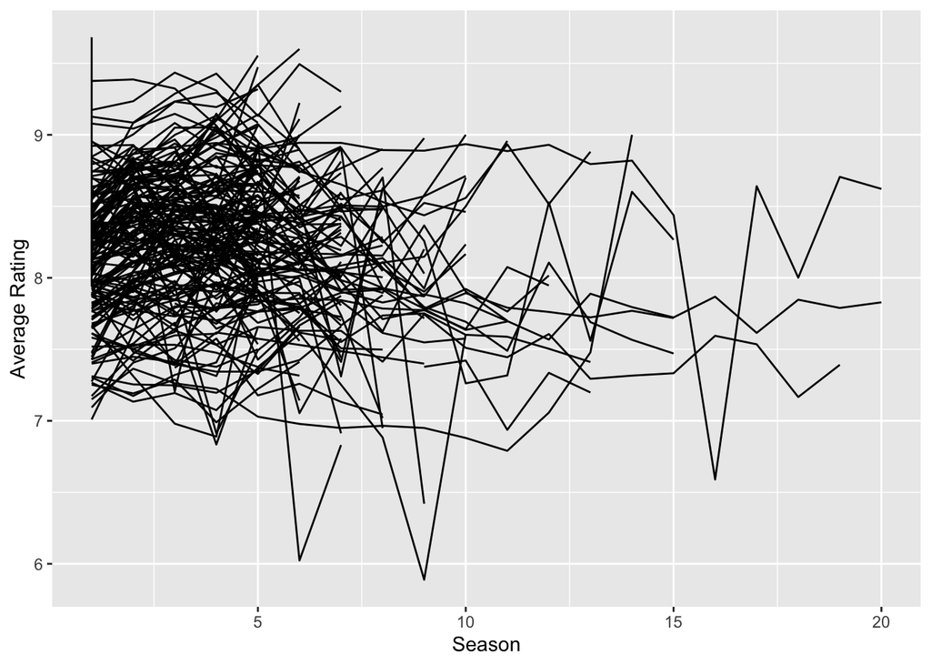

```r
tv_long <- tv_ratings |>
  group_by(title) |>
  summarise(num_seasons = n()) |>
  ungroup() |>
  left_join(tv_ratings, by = "title")

tv_long <- tv_long |>
  filter(num_seasons >= 5)

tv_long |>
  ggplot(aes(x = seasonNumber,
             y = av_rating,
             group = title)) +
  geom_line() +
  labs(x = "Season",
       y = "Average Rating")
```

## Question 2

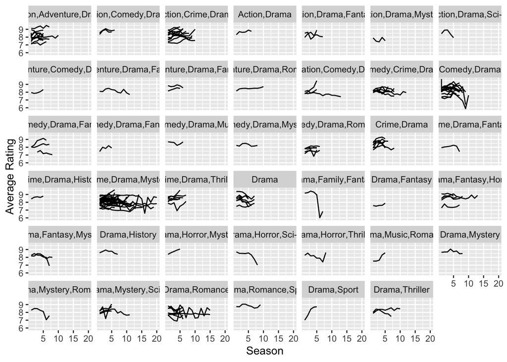

```r
tv_long |>
  ggplot(aes(x = seasonNumber,
             y = av_rating,
             group = title)) +
  geom_line() +
  labs(x = "Season",
       y = "Average Rating") +
  facet_wrap(~genres)
```

‘Crime, Drama, and Mystery’ and ‘Drama, Romance’ genres appear to be the two shows that lasted the longest. The show whose ratings plummeted is ‘Are You Afraid of the Dark.’

## Question 3

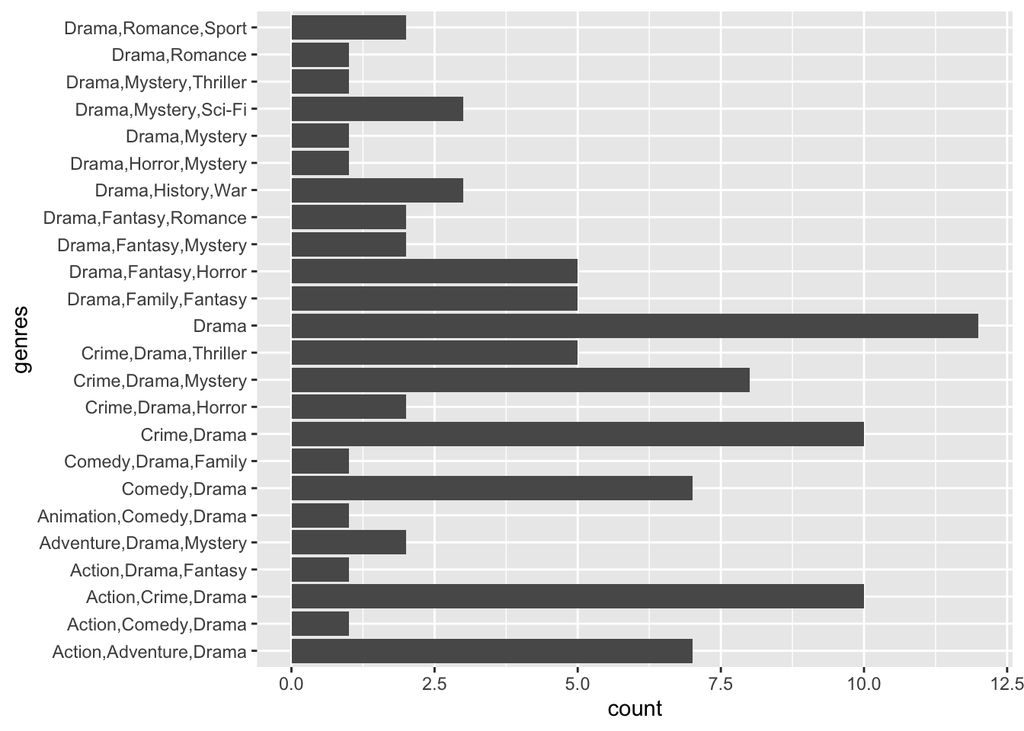

```r
best_rated <- tv_ratings |>
  filter(av_rating >= 9)

best_rated |>
  ggplot(aes(x = genres)) +
  geom_bar() +
  coord_flip()
```

Coord_flip() changes the x and y axis. Drama has the most top-rated shows with 12 shows.

## Question 4

```r
comedies_dramas <- tv_ratings |>
  mutate(is_comedy = if_else(str_detect(genres, "Comedy"), 1, 0)) |>
  filter(is_comedy == 1 | genres == "Drama") |>
  mutate(genres = if_else(genres == "Drama","Drama","Comedy"))

glimpse(comedies_dramas)
```

```
Rows: 684
Columns: 8
$ titleId      <chr> "tt0312081", "tt0312081", "tt0312081", "tt1225901", "tt12…
$ seasonNumber <dbl> 1, 2, 3, 1, 2, 3, 4, 5, 1, 2, 1, 25, 1, 1, 2, 3, 4, 5, 1,…
$ title        <chr> "8 Simple Rules", "8 Simple Rules", "8 Simple Rules", "90…
$ date         <date> 2002-09-17, 2003-11-04, 2004-11-12, 2009-01-03, 2009-11-…
$ av_rating    <dbl> 7.5000, 8.6000, 8.4043, 7.1735, 7.4686, 7.6858, 6.8344, 7…
$ share        <dbl> 0.03, 0.10, 0.06, 0.40, 0.14, 0.10, 0.04, 0.01, 0.48, 0.4…
$ genres       <chr> "Comedy", "Comedy", "Comedy", "Comedy", "Comedy", "Comedy…
$ is_comedy    <dbl> 1, 1, 1, 1, 1, 1, 1, 1, 1, 1, 0, 1, 1, 1, 1, 1, 1, 1, 1, …
```

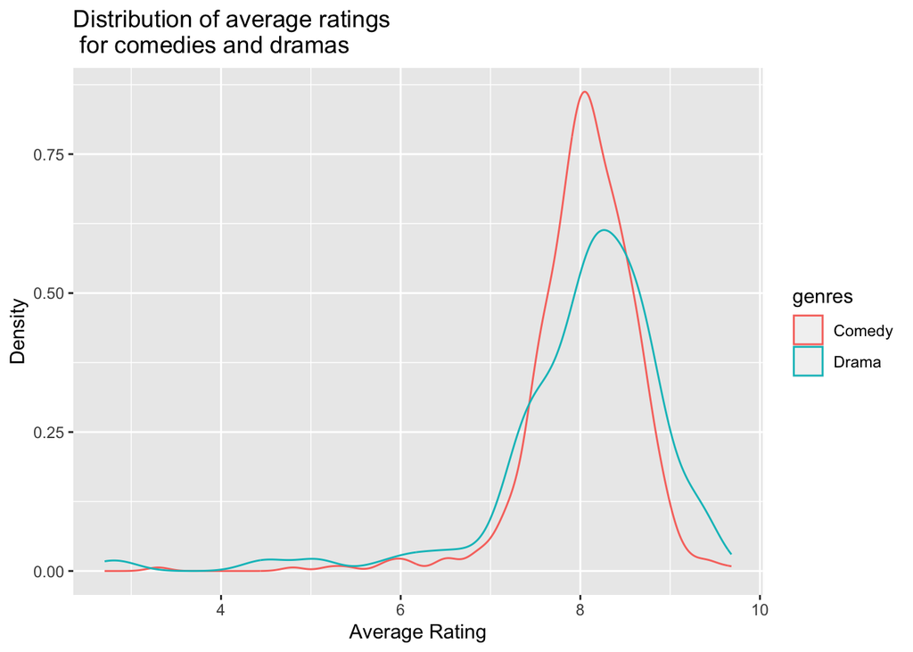

```r
comedies_dramas |>
  ggplot(aes(x = av_rating, group = genres, color = genres)) +
  geom_density() +
  labs(x = "Average Rating",
       y = "Density",
       title = "Distribution of average ratings \n for comedies and dramas")
```

## Question 5

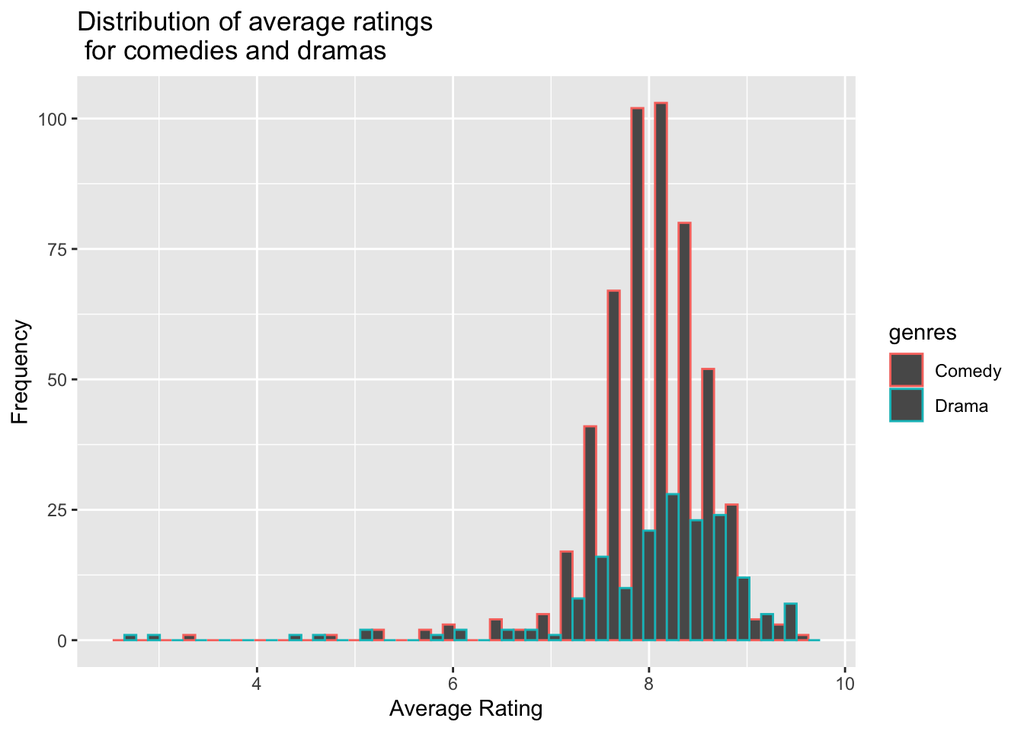

```r
comedies_dramas |>
  ggplot(aes(x = av_rating, group = genres, color = genres)) +
  geom_histogram(position = "dodge") +
  labs(x = "Average Rating",
       y = "Frequency",
       title = "Distribution of average ratings \n for comedies and dramas")
```

The histogram shows us how many shows there are for each genre in this dataset by mapping the frequency and spread of ratings. We are looking at more comedies than dramas in this set.

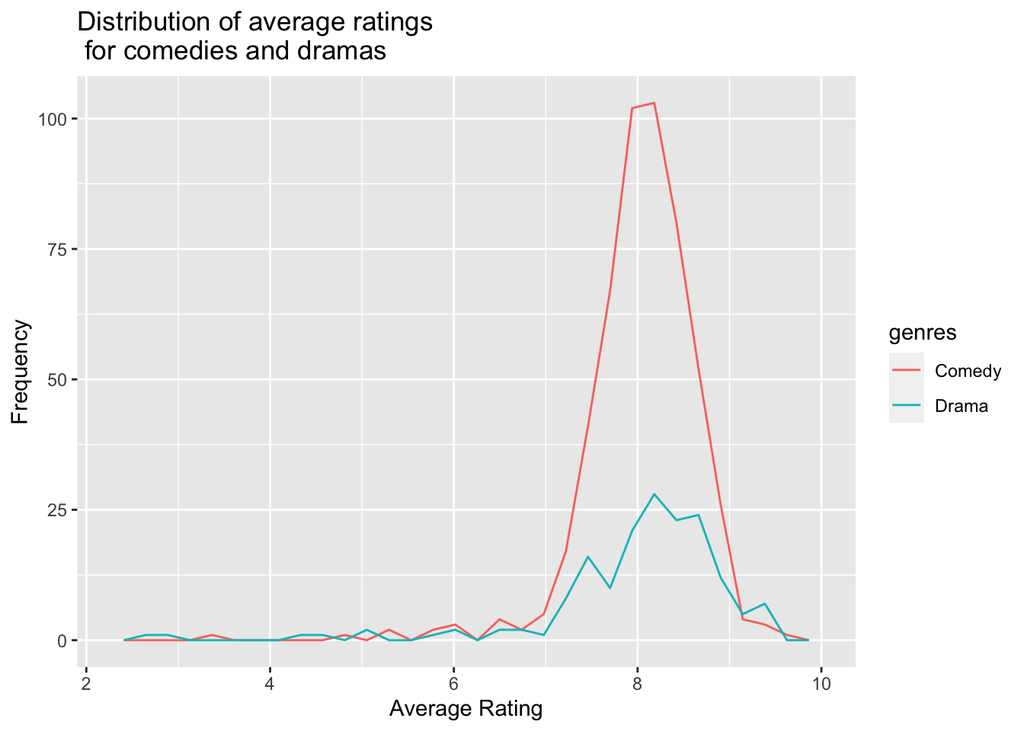

```r
comedies_dramas |>
  ggplot(aes(x = av_rating, group = genres, color = genres)) +
  geom_freqpoly() +
  labs(x = "Average Rating",
       y = "Frequency",
       title = "Distribution of average ratings \n for comedies and dramas")
```

The geom_freqpoly shows us the frequency of shows and their ratings as well as the distribution, allowing us to see the peaks and valleys in the distribution. I think this is the most informative because it shows both of these elements without a smooth line so we can see more data points in the distribution.

## Question 6

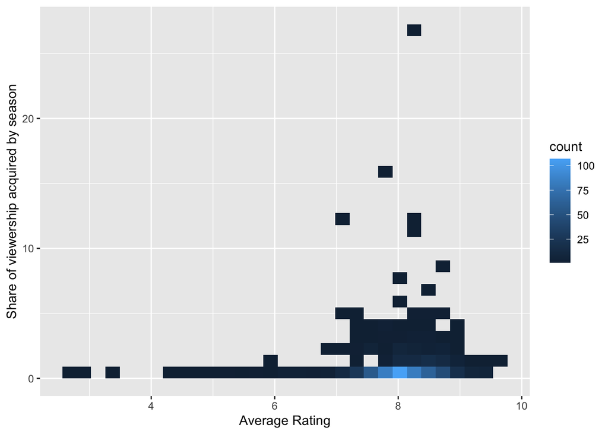

```r
comedies_dramas |>
  ggplot(aes(x = av_rating, y = share)) +
  geom_bin_2d() +
  labs(x = "Average Rating",
       y = "Share of viewership acquired by season")
```

This new visualization shows us the same shaped distribution clustered around an average rating of 8. The 2d bin plot shows us the density of data points in each region, which makes it easier to visualize the distribution of data and see where points are more concentrated.

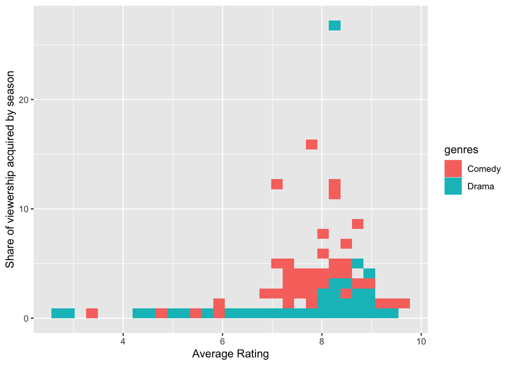

```r
comedies_dramas |>
  ggplot(aes(x = av_rating, y = share, fill = genres)) +
  geom_bin_2d() +
  labs(x = "Average Rating",
       y = "Share of viewership acquired by season")
```

Adding the fill aesthetic shows us the same plot but according to genre. Most comedies are around a rating of 8 whereas dramas are more spread out from 4-10. The big outlier appears to have been a season of the Drama named Dekalog rated around 8 which acquired lots of viewership for its show.